# Load MNIST data

```python
import torch
import numpy as np
from torchvision import datasets
import torchvision.transforms as transforms

# number of subprocesses to use for data loading
num_workers = 0
# how many samples per batch to load
batch_size = 20

# convert data to torch.FloatTensor
transform = transforms.ToTensor()

# choose the training and test datasets
train_data = datasets.MNIST(root='data', train=True,
                                   download=True, transform=transform)
test_data = datasets.MNIST(root='data', train=False,
                                  download=True, transform=transform)

# prepare data loaders
train_loader = torch.utils.data.DataLoader(train_data, batch_size=batch_size,
    num_workers=num_workers)
test_loader = torch.utils.data.DataLoader(test_data, batch_size=batch_size,
    num_workers=num_workers)
```

# Explanation for the code

```
import matplotlib.pyplot as plt
%matplotlib inline

# obtain one batch of training images
dataiter = iter(train_loader)
images, labels = dataiter.next()
images = images.numpy()

# plot the images in the batch, along with the corresponding labels
fig = plt.figure(figsize=(25, 4))
for idx in np.arange(20):
    ax = fig.add_subplot(2, 20/2, idx+1, xticks=[], yticks=[])
    ax.imshow(np.squeeze(images[idx]), cmap='gray')
    # print out the correct label for each image
    # .item() gets the value contained in a Tensor
    ax.set_title(str(labels[idx].item()))
```

## Documentation & Tutorial

- https://pytorch.org/tutorials/beginner/blitz/cifar10_tutorial.html
- https://scipy-lectures.org/advanced/image_processing/index.html
- https://matplotlib.org/3.1.0/tutorials/introductory/pyplot.html

## Index

1. iter()
2. images.numpy()
3. plt.figure()
4. fig.add.subplot()
5. imshow()
6. np.squeeze()

# iter()

- https://stackoverflow.com/questions/53464247/how-does-images-labels-dataiter-next-work-in-pytorch-tutorial
- iter() make an object into iterable object that next() method can be used on
- Example

  ```
  test = (1,2,3)
  tester = iter(test)
  while True:
    nextItem = next(tester)
    print(nextItem)
  ```

```python
import matplotlib.pyplot as plt
%matplotlib inline

# obtain one batch of training images
dataiter = iter(train_loader)
images, labels = dataiter.next()
    # read one batch (in this case, 20 images and labels)

print(train_loader)
print(dataiter)
```

```
<torch.utils.data.dataloader.DataLoader object at 0x7f5b1814e978>
<torch.utils.data.dataloader._DataLoaderIter object at 0x7f5ae6367e80>
```

## tensor.numpy()

- convert torch tensor into numpy obejct

```python
print(images.shape)

images = images.numpy() # convert torch tensor into numpy tensor

print(images.shape)
```

```
torch.Size([20, 1, 28, 28])
(20, 1, 28, 28)
```

# matplotlib.pyplot.figure

- Create a new figure
- https://matplotlib.org/3.1.0/api/_as_gen/matplotlib.pyplot.figure.html

```
matplotlib.pyplot.figure(
    num=None,
    figsize=None,
    dpi=None,
    facecolor=None,
    edgecolor=None,
    frameon=True,
    FigureClass=<class 'matplotlib.figure.Figure'>,
    clear=False,
    **kwargs)
```

- num : integer or string, optional, default: None  
  If not provided, a new figure will be created, and the figure number will be incremented.  
  The figure objects holds this number in a number attribute. If num is provided, and a figure with this id already exists,  
  make it active, and returns a reference to it. If this figure does not exists,  
  create it and returns it. If num is a string, the window title will be set to this figure's num.
- figsize : (float, float), optional, default: None  
  width, height in inches. If not provided, defaults to rcParams["figure.figsize"] = [6.4, 4.8].

```python
fig = plt.figure(figsize=(25, 4))
```

# matplotlib.pyplot.subplot

- Create a figure and a set of subplots.
- https://matplotlib.org/3.1.0/api/_as_gen/matplotlib.pyplot.subplot.html

```
matplotlib.pyplot.subplot(*args, **kwargs)

call signatures:
    subplot(nrows, ncols, index, **kwargs)
    subplot(pos, **kwargs)
    subplot(ax)
```

- *args  
  Either a 3-digit integer or three separate integers describing the position of the subplot.  
  If the three integers are nrows, ncols, and index in order,  
  the subplot will take the index position on a grid with nrows rows and ncols columns.  
  index starts at 1 in the upper left corner and increases to the right.

  pos is a three digit integer,  
  where the first digit is the number of rows,  
  the second the number of columns,  
  and the third the index of the subplot.  
  i.e. fig.add_subplot(235) is the same as fig.add_subplot(2, 3, 5).  
  Note that all integers must be less than 10 for this form to work.

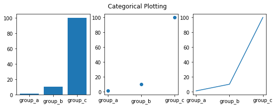

```python
# just example from tutorial

names = ['group_a', 'group_b', 'group_c']
values = [1, 10, 100]

plt.figure(figsize=(9, 3))

plt.subplot(131)
plt.bar(names, values)
plt.subplot(132)
plt.scatter(names, values)
plt.subplot(133)
plt.plot(names, values)
plt.suptitle('Categorical Plotting')
plt.show()
```

# matplotlib - imshow

## Documentation & Tutorial

- https://matplotlib.org/3.1.0/api/_as_gen/matplotlib.pyplot.imshow.html
- https://matplotlib.org/users/image_tutorial.html

## What does it?

Display an image

## Usage

matplotlib.pyplot.imshow(X, .......)

belwo explanation is from documentation above, see it for more details

X : array-like or PIL image The image data. Supported array shapes are:

(M, N): an image with scalar data. The data is visualized using a colormap.  
(M, N, 3): an image with RGB values (0-1 float or 0-255 int).  
(M, N, 4): an image with RGBA values (0-1 float or 0-255 int), i.e. including transparency.  
The first two dimensions (M, N) define the rows and columns of the image.

# numpy.squezze

## Documentation & Tutorial

- https://docs.scipy.org/doc/numpy/reference/generated/numpy.squeeze.html
- https://www.geeksforgeeks.org/numpy-squeeze-in-python/

## What does it?

Remove single-dimensional entries from the shape of an array.

## Usage

numpy.squeeze(a, axis=None)

Parameters:

- a : array_like ; Input data.
- axis : None or int or tuple of ints, optional  
  New in version 1.7.0.  
  Selects a subset of the single-dimensional entries in the shape.  
  If an axis is selected with shape entry greater than one, an error is raised.

Returns:

- squeezed : ndarray  
  The input array, but with all or a subset of the dimensions of length 1 removed.  
  This is always a itself or a view into a.

Raises:

- ValueError  
  If axis is not None, and an axis being squeezed is not of length 1

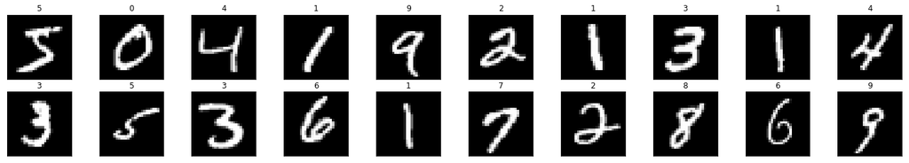

```python
# plot the images in the batch, along with the corresponding labels
fig = plt.figure(figsize=(25, 4))
for idx in np.arange(20):
    ax = fig.add_subplot(2, 20/2, idx+1, xticks=[], yticks=[])
    ax.imshow(np.squeeze(images[idx]), cmap='gray')
    # print out the correct label for each image
    # .item() gets the value contained in a Tensor
    ax.set_title(str(labels[idx].item()))
```

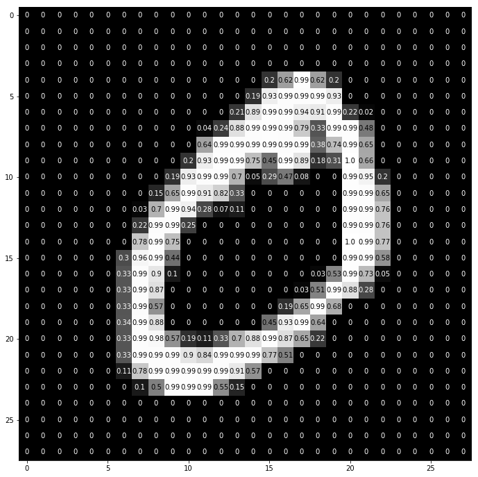

```python
img = np.squeeze(images[1])

fig = plt.figure(figsize = (12,12))
ax = fig.add_subplot(111)
ax.imshow(img, cmap='gray')
width, height = img.shape
thresh = img.max()/2.5
for x in range(width):
    for y in range(height):
        val = round(img[x][y],2) if img[x][y] !=0 else 0
        ax.annotate(str(val), xy=(y,x),
                    horizontalalignment='center',
                    verticalalignment='center',
                    color='white' if img[x][y]<thresh else 'black')
```

# Define Network

```python
import torch.nn as nn
import torch.nn.functional as F

# define the NN architecture
class Net(nn.Module):
    def __init__(self):
        super(Net, self).__init__()
        # number of hidden nodes in each layer (512)
        hidden_1 = 512
        hidden_2 = 512
        # linear layer (784 -> hidden_1)
        self.fc1 = nn.Linear(28 * 28, hidden_1)
        # linear layer (n_hidden -> hidden_2)
        self.fc2 = nn.Linear(hidden_1, hidden_2)
        # linear layer (n_hidden -> 10)
        self.fc3 = nn.Linear(hidden_2, 10)
        # dropout layer (p=0.2)
        # dropout prevents overfitting of data
        self.dropout = nn.Dropout(0.2)

    def forward(self, x):
        # flatten image input
        x = x.view(-1, 28 * 28)
        # add hidden layer, with relu activation function
        x = F.relu(self.fc1(x))
        # add dropout layer
        x = self.dropout(x)
        # add hidden layer, with relu activation function
        x = F.relu(self.fc2(x))
        # add dropout layer
        x = self.dropout(x)
        # add output layer
        x = self.fc3(x)
        return x

# initialize the NN
model = Net()
print(model)
```

```
Net(
  (fc1): Linear(in_features=784, out_features=512, bias=True)
  (fc2): Linear(in_features=512, out_features=512, bias=True)
  (fc3): Linear(in_features=512, out_features=10, bias=True)
  (dropout): Dropout(p=0.2)
)
```

# Loss Function and Optimizer

```python
# specify loss function (categorical cross-entropy)
criterion = nn.CrossEntropyLoss()

# specify optimizer (stochastic gradient descent) and learning rate = 0.01
optimizer = torch.optim.SGD(model.parameters(), lr=0.01)
```

# Train

```python
# number of epochs to train the model
n_epochs = 1 # 20~50 recommended

model.train() # prep model for training

for epoch in range(n_epochs):
    # monitor training loss
    train_loss = 0.0

    ###################
    # train the model #
    ###################
    for data, target in train_loader:
        # clear the gradients of all optimized variables
        optimizer.zero_grad()
        # forward pass: compute predicted outputs by passing inputs to the model
        output = model(data)
        # calculate the loss
        loss = criterion(output, target)
        # backward pass: compute gradient of the loss with respect to model parameters
        loss.backward()
        # perform a single optimization step (parameter update)
        optimizer.step()
        # update running training loss
        train_loss += loss.item()*data.size(0)

    # print training statistics
    # calculate average loss over an epoch
    train_loss = train_loss/len(train_loader.sampler)

    print('Epoch: {} \tTraining Loss: {:.6f}'.format(
        epoch+1,
        train_loss
        ))
```

```
Epoch: 1 	Training Loss: 0.813940
```

# Test

```python
# initialize lists to monitor test loss and accuracy
test_loss = 0.0
class_correct = list(0. for i in range(10))
class_total = list(0. for i in range(10))


with torch.no_grad(): # freeze

    model.eval() # prep model for *evaluation*

    for data, target in test_loader:
        # forward pass: compute predicted outputs by passing inputs to the model
        output = model(data)
        # calculate the loss
        loss = criterion(output, target)
        # update test loss
        test_loss += loss.item()*data.size(0)
        # convert output probabilities to predicted class
        _, pred = torch.max(output, 1)
        # compare predictions to true label
        correct = np.squeeze(pred.eq(target.data.view_as(pred)))
        # calculate test accuracy for each object class
        for i in range(len(target)):
            label = target.data[i]
            class_correct[label] += correct[i].item()
            class_total[label] += 1

# calculate and print avg test loss
test_loss = test_loss/len(test_loader.sampler)
print('Test Loss: {:.6f}\n'.format(test_loss))

for i in range(10):
    if class_total[i] > 0:
        print('Test Accuracy of %5s: %2d%% (%2d/%2d)' % (
            str(i), 100 * class_correct[i] / class_total[i],
            np.sum(class_correct[i]), np.sum(class_total[i])))
    else:
        print('Test Accuracy of %5s: N/A (no training examples)' % (classes[i]))

print('\nTest Accuracy (Overall): %2d%% (%2d/%2d)' % (
    100. * np.sum(class_correct) / np.sum(class_total),
    np.sum(class_correct), np.sum(class_total)))
```

```
Test Loss: 0.336933

Test Accuracy of     0: 98% (964/980)
Test Accuracy of     1: 98% (1119/1135)
Test Accuracy of     2: 84% (874/1032)
Test Accuracy of     3: 88% (896/1010)
Test Accuracy of     4: 91% (896/982)
Test Accuracy of     5: 83% (749/892)
Test Accuracy of     6: 92% (885/958)
Test Accuracy of     7: 87% (904/1028)
Test Accuracy of     8: 82% (800/974)
Test Accuracy of     9: 91% (919/1009)

Test Accuracy (Overall): 90% (9006/10000)
```